# Task 2: Willamette Falls Fish Passage

German Silva

3/3/2022

```r
knitr::opts_chunk$set(echo = TRUE, warning = FALSE, message = FALSE)

# attach packages
library(tidyverse)
library(here)
library(lubridate)
library(tsibble)
library(feasts)
library(slider)
library(patchwork)
```

# Overview

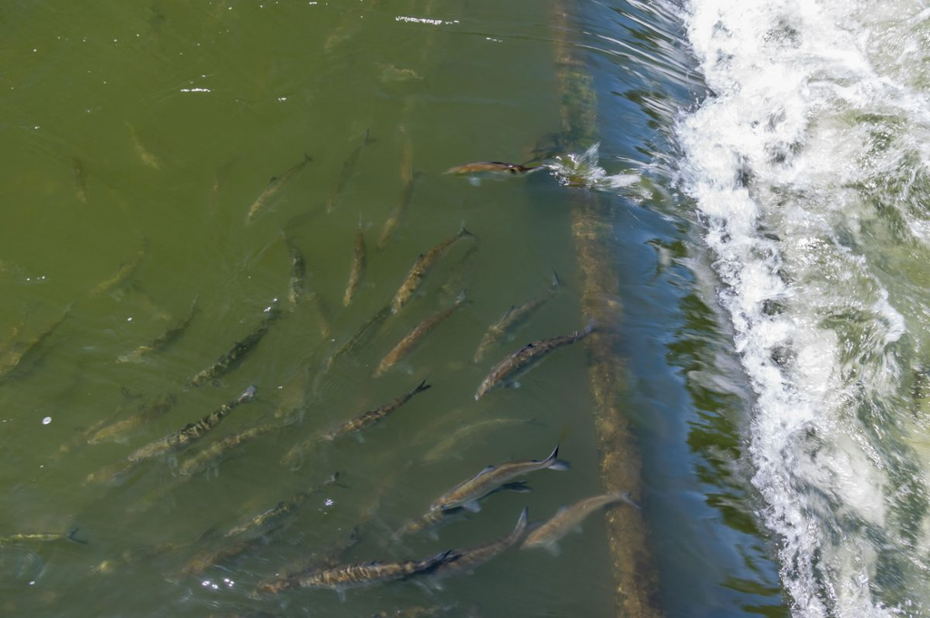

**Caption**: Salmon swimming up a fish ladder. Photo by John Trax/Alamy Stock Photo

**Summary**:

This report explores a subset of the adult fish passage data from the Willamette Falls fish ladder on the Willamette River (Oregon, USA) from 2001-01-01 to 2010-12-31. The analyses focus on three types of salmon: coho, jack coho, and steelhead. A variety of time series visualization and analysis techniques are highlighted. Analysis of the data includes 1) visualization of the original times series, 2) seasonplots for the data, and 3) annual counts by species.

**Data Source**:

Columbia River Research, “Data Access in Real Time (DART) Adult Passage Graphics and Text”, http://www.cbr.washington.edu/dart/query/adult_graph_text

## Original Time Series

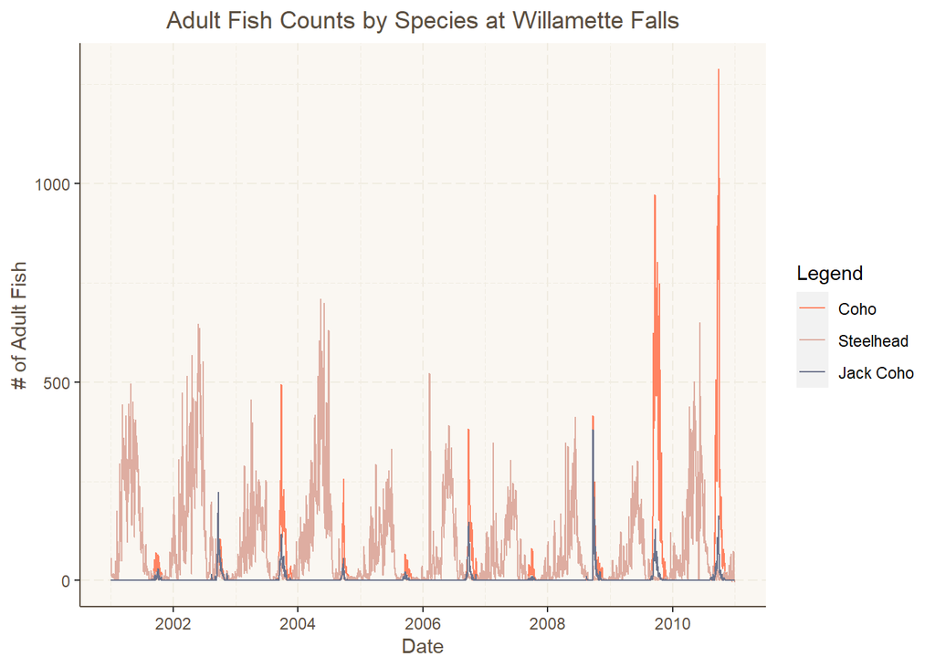

**Fig. 1** Plots showing the counts of the fish for each date. From each plot we can get a general sense of how the three fish differ in their seasonality.

```r
# opening the data and subsetting for salmon of interest and creating time series data
adult_pass <- read_csv(here('data', 'willamette_fish_passage.csv')) %>%
  janitor::clean_names() %>%
  select(date, coho, steelhead, jack_coho) %>%
  mutate(date = mdy(date)) %>%
  as_tsibble(key = NULL, index = date)

# changing NA values to 0
adult_pass[is.na(adult_pass)] = 0

adult_pass_long <- adult_pass %>%
  pivot_longer(!date, names_to = "species", values_to = "count")

# create the three ggplots visualizing the three time series

ggplot(adult_pass, aes(x = date))+
  geom_line(aes(y = coho, color = "Coho")) +
  geom_line(aes(y = steelhead, color = "Steelhead")) +
  geom_line(aes(y = jack_coho, color = "Jack Coho")) +
  labs(x = "Date",
       y = "# of Adult Fish",
       color = "Legend")+
  scale_color_manual(values = c("Coho" = "#ff8362", "Steelhead" = "#DEADA1", "Jack Coho" = "#6d748c"))+
  ggtitle("Adult Fish Counts by Species at Willamette Falls")+
  theme(plot.title = element_text(color = "#5b4f41", hjust = 0.5),
            plot.background = element_rect("white"),
            panel.background = element_rect("#faf7f2"),
            panel.grid = element_line(linetype= "longdash", color = "#f0ece1"),
            axis.text = element_text(color = "#5b4f41"),
            axis.title = element_text(color = "#5b4f41"),
            strip.background = element_rect("white"),
            axis.line = element_line(color = "#5b4f41"))
```

**Takeaway Points**:

- Steelhead numbers seem to spike at a different time of year than Coho and Jack Coho
- Coho and Jack Coho numbers are much more punctuated than the Steelhead numbers
- Coho numbers seem to be increasing over time

## Seasonplots

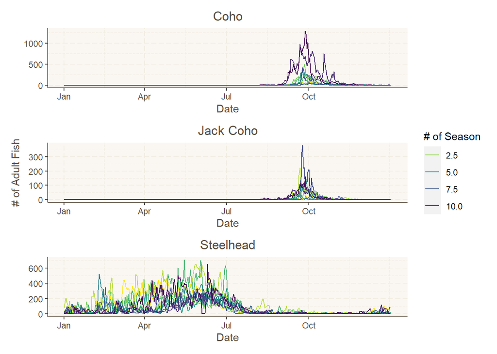

**Fig. 2** Season Plots for all ten years for each species of fish. Earlier seasons are colored in a light color and darker colors represent later seasons. Both types of Coho peak around October, while Steelhead peak around June.

```r
# create a season plot for each species
coho_seaon <- adult_pass %>%
  gg_season(y = coho) +
  theme(plot.title = element_text(color = "#5b4f41", hjust = 0.5),
            plot.background = element_rect("white"),
            panel.background = element_rect("#faf7f2"),
            panel.grid = element_line(linetype= "longdash", color = "#f0ece1"),
            axis.text = element_text(color = "#5b4f41"),
            axis.title = element_text(color = "#5b4f41"),
            strip.background = element_rect("white"),
            axis.line = element_line(color = "#5b4f41"),
            legend.position = "none")+
  scale_colour_viridis_c(direction = -1) +
  labs(x = "Date",
       y = "")+
  ggtitle("Coho")

steelhead_season <- adult_pass %>%
   gg_season(y = steelhead) +
  theme(plot.title = element_text(color = "#5b4f41", hjust = 0.5),
            plot.background = element_rect("white"),
            panel.background = element_rect("#faf7f2"),
            panel.grid = element_line(linetype= "longdash", color = "#f0ece1"),
            axis.text = element_text(color = "#5b4f41"),
            axis.title = element_text(color = "#5b4f41"),
            strip.background = element_rect("white"),
            axis.line = element_line(color = "#5b4f41"),
            legend.position = "none")+
  scale_color_viridis_c(direction = -1)+
  labs(x = "Date",
       y =  "")+
  ggtitle("Steelhead")

jack_season <- adult_pass %>%
   gg_season(y = jack_coho) +
  theme(plot.title = element_text(color = "#5b4f41", hjust = 0.5),
            plot.background = element_rect("white"),
            panel.background = element_rect("#faf7f2"),
            panel.grid = element_line(linetype= "longdash", color = "#f0ece1"),
            axis.text = element_text(color = "#5b4f41"),
            axis.title = element_text(color = "#5b4f41"),
            strip.background = element_rect("white"),
            axis.line = element_line(color = "#5b4f41"))+
  scale_color_viridis_c(direction = -1)+
  labs(x = "Date",
       y = "# of Adult Fish",
       color = "# of Season")+
  ggtitle("Jack Coho")

patchwork <- coho_seaon /jack_season / steelhead_season

patchwork
```

**Takeaway Points**:

- Coho and Jack Coho salmon have similar seasonality
- Coho and Jack Coho numbers seem to be on the rise as time goes on
- Steelhead numbers peak around April to July and don’t show as clear of an increase as Jack Coho and Coho

## Annual counts by species

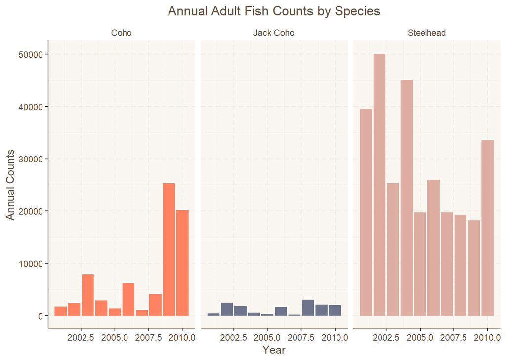

```r
adult_annual <- adult_pass_long %>%
  index_by(year = ~year(.)) %>%
  group_by(species, year) %>%
  summarize(annual_sum = sum(count))

species.labs <- c("coho" = "Coho", "jack_coho" = "Jack Coho", "steelhead" = "Steelhead")

ggplot(adult_annual, aes(x = year, y = annual_sum, fill = species))+
  geom_bar(stat = "identity")+
  facet_wrap(~species, labeller = labeller(species = species.labs))+
  scale_fill_manual(values = c("coho" = "#ff8362", "steelhead" = "#DEADA1", "jack_coho" = "#6d748c"))+
  ggtitle("Annual Adult Fish Counts by Species")+
  labs(x = "Year",
       y = "Annual Counts",
       fill = "Species")+
  theme(plot.title = element_text(color = "#5b4f41", hjust = 0.5),
            plot.background = element_rect("white"),
            panel.background = element_rect("#faf7f2"),
            panel.grid = element_line(linetype= "longdash", color = "#f0ece1"),
            axis.text = element_text(color = "#5b4f41"),
            axis.title = element_text(color = "#5b4f41"),
            strip.background = element_rect("white"),
        strip.text = element_text(color = "#5b4f41"),
            axis.line = element_line(color = "#5b4f41"),
        legend.position = "none")
```

**Takeaway Points**:

- Jack Coho have the lowest annual counts out of the three species assessed
- Annual Coho numbers seem to be on the rise between 2000 and 2010.
- Despite Coho having the largest peak on daily passages, as seen in Fig. 1, steelhead have the largest number of annual passings.